# Is the RNN brain-like?

Python

Neural Networks

RNN

Graph Theory

Published

June 6, 2026

In the previous tutorial we cleaned up the RNN’s `W_rec`, until, in *format*, it was exactly like the brain connectivity matrix. We could finally lay the two side by side.

But eyeballing only gets us so far. Now for the real test: do they have the same **topology**? In other words, is our RNN actually wired like a brain, or does it just happen to be the same shape of grid?

## Two summary measures

In the Topology tutorial we measured several properties of brain networks. Here we’ll introduce **two** more summary measures that, together, capture the brain’s signature organisation. Let’s build an intuition for each.

### Modularity — does the network form modules?

The first measure is **modularity**. It asks whether the network breaks up into **modules**: groups of nodes that are densely wired *to each other* but only loosely connected to the rest.

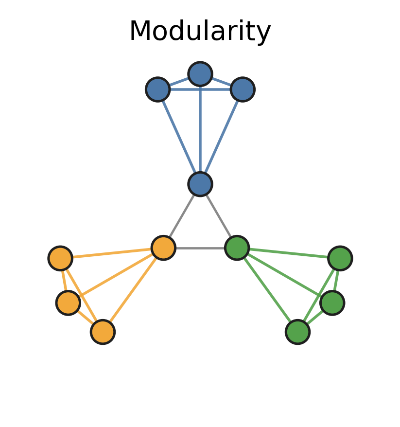

In the little network above there are three clear modules (blue, orange, green). Inside each one, every node talks to its neighbours, while only a single thin bridge links one module to the next. A network like this has **high modularity**. Brains are modular in exactly this way: visual areas wire mostly to other visual areas, motor areas to motor areas, and so on. So modularity measures **segregation** — how much a network keeps its specialised parts to themselves.

### Global efficiency — how far apart is everything?

The second measure is **global efficiency**. It asks almost the opposite question: starting from any node, how *few* steps does it take to reach any other node?

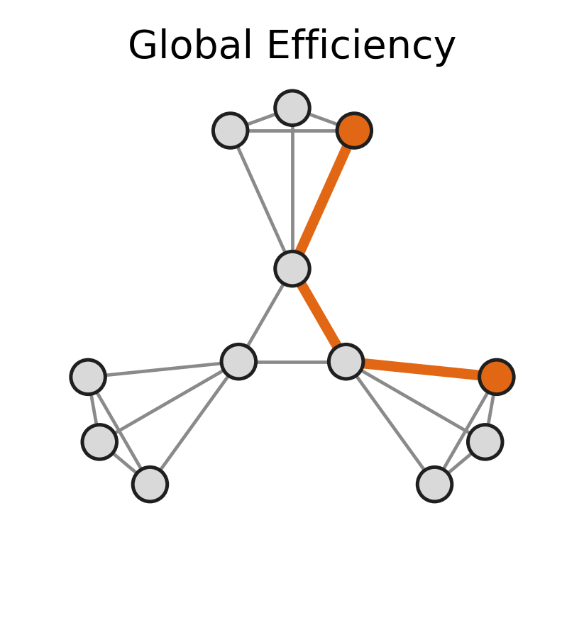

Here we’ve highlighted the shortest route between two nodes that sit in *different* modules, and it’s only a couple of hops. When *every* pair of nodes can be reached in just a few steps, the network has **high global efficiency**. Brains are remarkably efficient: even though they’re carved into modules, a signal can still get from almost anywhere to anywhere in a handful of steps. So efficiency measures **integration** — how easily the whole network can act as one.

### The best of both worlds

Here’s the beautiful part: brains manage to be **both** highly modular **and** highly efficient *at the same time* — specialised modules that are nonetheless all closely linked. That combination is called a **small-world** network, and it’s one of the most reliable signatures of brain organisation. So if our RNN is truly brain-like, it should score high on *both* measures, landing right next to the brains.

## Why *weighted* metrics?

A quick but important choice. Back in Section 1 we often reduced networks to **binary** (a connection is either there or not). But all our matrices are **weighted**: the *strength* of each connection carries real information (streamline counts for brains, learned weights for the RNN). Throwing that away would be a pity!

So here we use the **weighted** versions of both measures: a strong connection counts for more when forming a module, and acts as a better **shortcut** when measuring efficiency (a strong link = a short hop).

## Wait… are we ready to compare?

Amazing, it looks like everything is ready to compare our networks! …Or maybe not!!! If you did our Preprocessing tutorial, you’ll remember there are **two more things** we have to take care of before any two networks can be compared fairly.

### 1. The same density

The two networks must have the same **density** — the same number of connections. We saw in Preprocessing that density and topology are tightly linked (a denser network is automatically more efficient and less modular), so comparing networks at *different* densities would tell us nothing. The brains were already trimmed to a common density back then; we now do the same to the RNN, keeping only its **strongest** connections until it matches.

Putting that together with the clean-up from the last tutorial (positive, symmetric, no diagonal, rescaled to 0–1), our full preprocessing is just:

```python
import numpy as np

def preprocess(W, density=None):
    W = np.abs(W)                 # strengths, not signs   (last tutorial)
    W = (W + W.T) / 2             # symmetrise             (last tutorial)
    np.fill_diagonal(W, 0)        # no self-connections    (last tutorial)
    if density is not None:       # NEW: keep only the strongest connections
        triu = W[np.triu_indices_from(W, k=1)]
        threshold = np.sort(triu)[::-1][int(len(triu) * density)]
        W = np.where(W >= threshold, W, 0)
    return W / W.max()            # rescale to 0–1 so the two scales match
```

### 2. Fully connected

The second requirement is that the network be **fully connected**: you should be able to travel from any node to any other. This matters here because global efficiency is all about the paths between nodes, and a node with no connections has no paths at all. The brains all passed this check in the Preprocessing tutorial. Let’s check the RNN, once it’s been trimmed to the brains’ density:

```python
import networkx as nx

W_rec = preprocess(W_rec, density=0.18)
print(nx.is_connected(nx.from_numpy_array(W_rec)))   # -> False!
```

Interesting!! Once trimmed to the brains’ density, the RNN turns out **not** to be fully connected: a few units get cut off completely. That’s already our first hint that its wiring is unlike a brain’s. Happily, global efficiency handles this gracefully (an unreachable pair of nodes simply contributes zero), so we can still measure both networks on equal terms.

## Measuring weighted topology

Now the two metrics. **Modularity** is a one-liner with `networkx` (it finds communities and scores how modular they are, using the weights):

```python
import networkx as nx

def weighted_modularity(W):
    G = nx.from_numpy_array(W)
    communities = nx.community.louvain_communities(G, weight="weight", seed=42)
    return nx.community.modularity(G, communities, weight="weight")
```

For **efficiency** we turn each connection *strength* into a *distance* (a strong connection is a **short** hop), find the shortest weighted path between every pair of nodes, and average `1 / distance`:

```python
def weighted_efficiency(W):
    G = nx.from_numpy_array(W)
    for _, _, d in G.edges(data=True):
        d["dist"] = 1 / d["weight"]          # strong connection -> short distance
    n, total = G.number_of_nodes(), 0.0
    for src, lengths in nx.all_pairs_dijkstra_path_length(G, weight="dist"):
        for tgt, dist in lengths.items():
            if src != tgt:
                total += 1 / dist            # efficiency of this pair
    return total / (n * (n - 1))
```

We run both on the trained RNN and on each of our 20 brains, and plot the results.

## The verdict

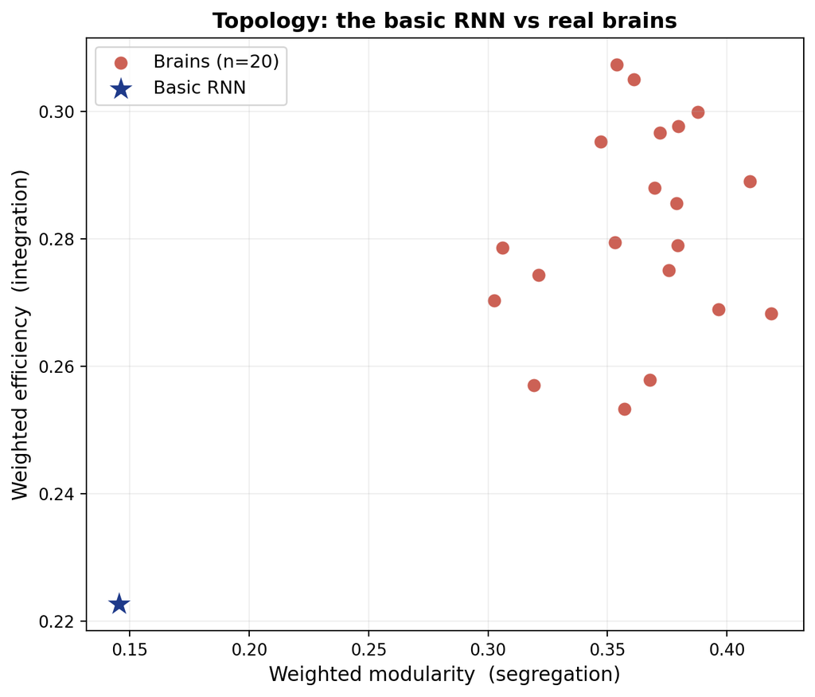

The result is stark. The 20 brains huddle together in the **top-right**: highly modular *and* highly efficient, exactly as small-world networks should be. Our basic RNN (the blue star) sits far away in the **bottom-left**, with **much lower modularity** (≈ 0.15 vs the brains’ ≈ 0.36) **and lower efficiency** (≈ 0.22 vs ≈ 0.28) than *any* of the brains.

So the answer to our title question is a clear **no**. A network trained to do one simple task does **not** spontaneously wire itself like a brain. It solved the job perfectly well, but with a flat, weakly-structured connectivity that looks nothing like the brain’s segregated-yet-integrated organisation.

## What’s next: nudging it towards the brain

That’s not a disappointment, it’s where things get interesting! If task-training alone doesn’t produce brain-like wiring, what *would*? We have two ideas to try in the coming tutorials:

1. **Give it a harder job.** A single Go/No-Go task is trivially easy, and an easy task simply doesn’t *demand* rich structure. Perhaps a network only develops brain-like, modular wiring when it has to juggle **many** tasks at once. We’ll train it on a whole battery of tasks and measure again.
2. **Bake in the brain’s wiring rules.** Remember the GNMs from Section 2? Real brains pay a **wiring cost**: long-range connections are metabolically expensive, so the brain prefers short ones (that was **η**, the distance penalty). We can add the *very same* distance-dependent constraint to the RNN’s training and see whether it pulls the topology towards the brains.

See you in the next tutorial, where we start making our RNN a little more brain-like! 🚀

Back to top